# Outcome

## Usability and validity of the D-score in a low income country: The example of Togo

The D-score is intended as a universal measure of children’s development. There is ample research indicating that the D-score actually is a valid indicator of development in western European countries like the Netherlands. If the D-score is a universal measure it should be informative in low and middle income countries as well. However, little is known about the usability and validity of the D-score in such countries. The aim of the present study is to examine the usability and validity of the D-score in the western African country of Togo. Togo definitely qualifies as a low income country with a 2017 GNI per capita of $610 versus $46,180 in the Netherlands, and $744 for low income countries in general (data.worldbank.org).  
To address this issue, we used data that were gathered by a French physician in Kpalimé, Togo. She set up a child health care system that was modeled after the Dutch preventive health care system. The system included the use of the so called Van Wiechen system to assess whether children’s developmental progress is in the normal range. The Van Wiechen data were used to calculate the D-scores as well as the age-corrected z-score of the D-score relative to a Dutch sample (DAZ). These two indices are the dependent variables in the present study. Data were gathered from about 9747 individuals in the 0-18 age range, but for the present study we focus on data from children in the 0-4 age range because the Van Wiechen assessment system is meant for this age range.  
Other available measures include father’s level of schooling, father’s number of children at the child’s first visit to the medical center, the APGAR score as a newborn, children’s weight, and the results of a physician’s neurological examination during visits to the health center. These variables are used to predict children’s D-scores and thereby to examine the D-score’s usability and validity in Togo.

**Methods**

Medical assessment  
At each visit a physician notated whether problems were observed regarding a wide renage of health aspects including problems with reflexes and muscle tension. Also, weight was measured at each visit.

Background characteristics  
At the first visit of each child, the accompanying adult (mostly the mother) was asked to report on general background characteristics, including profession of the parents and the number of children each of the parents has (due to polygamy this number may differ between parents). As a measure of socio-economic status (SES) we constructed a dichotomous variable ‘schooling of father’ based on the reported profession of the father. As the main physician and founder of the medical center is familiar with the local culture and schooling system, she indicated which of the thirteen most common professions were likely to be schooled professions (i.e. need more than primary education). Fathers with one of these professions were classified as ‘schooled’. When ‘another profession’ was marked, the father was categorized as unschooled.  
Other background characteristics included gender of the child, number of children of the father at the moment of the first visit, and birth date. Age of the child at the moment of visiting was calculated based on the date of visit and the birth date. In Togo, medical information about a newborn is notated on a special card which parents receive. Parents were asked to take this card to the medical center; in this way information about the birth situation of part of the children was obtained, including birth weight, gestational age (<37 weeks versus 37 weeks or more) and APGAR scores at 1, 5 and 10 minutes after birth.

Procedure  
Measures used in this study were assessed at the medical center in Kpalimé which parents visited with their children, and were part of a general preventive health assessment (including physical measurements of weight, height, and head size, a medical examination, a few blood tests, and a hearing test). Also, parents were asked to report on characteristics of the birth situation, previous health issues, nutrition situation, and background characteristics of the family.  
During the visits, medical assessment took place before assessment of the Van Wiechen assessment, and was conducted by the same physician. All assessments, including the Van Wiechen assessment, were either performed by the initiating physician and founder of the medical center, or by one of three local physicians trained to assess the Van Wiechen procedure. Resulting data of the assessment (including advice given and/or references to another professional) were documented in paper dossiers and in 2017 digitalized by four local assistants via software program EpiData.

Analyses  
To assess the validity of the D-score in this population, we inspected scatterplots in which d-scores are plotted against age for all available visits, and in which children with neurological problems as observed by a physician are highlighted. It was expected that a curve is seen, with higher d-scores for older children, moreover children with very low D-scores for their age were expected to be assessed by the physician as having a neurological problem. Validity and usability of the D-score in this population would also be supported when known risk factors of developmental problems would be found to be predictors of a lower D-score in this population as well. Risk factors of interest are health problems of a newborn (as indicated by a less than optimal APGAR score at 10 minutes), and being underweighted. Furthermore, if a relation between underweight and a lower D-score is observed, it would also be interesting to see whether there is a relation between family size and D-score, as many children per family could be a cause of malnutrition. For this purpose children were classified as being part of a large family when the number of children of their father was 5 or more (at the moment of their first visit) versus 4 or less.  
To assess which risk factors predict a lower than normal D-score, several regression analyses were conducted. Outcome variable is the Development - Age adjusted Z-score (DAZ) which tells how many standard deviations the D-score of the child deviates from his/her age mates. To calculate these z-scores, data of Dutch children are used as reference data. As this reference data is only available for children younger than age 2.78 years, only DAZ-scores could be calculated for age group 0 – 2.78, and therefore all regression analyses were performed for this subgroup.  
For some of the risk factor variables data is only available for part of the children. In order to prevent a loss of power, for each risk factor separate regression analyses were conducted. In each regression sex and education level of father (schooled versus unschooled) were added as covariates (except for the regression where the relation between large families and the DAZ is analyzed, as family size and schooling may be confounded). As data from visits of the same children are not independent, regressions were performed on data with one visit per child only. All regression analyses were conducted twice: once with the data from the first visit of each child, and once with the last visit of each child.

**Results**

Descriptives (last visit per child)

|  | N | mean | SD | median |
| --- | --- | --- | --- | --- |
| age | 1567 | 2.36 | 1.11 | 2.36 |
| D-score | 1507 | 63.66 | 12.98 | 68.01 |
| DAZ | 878 | 0.42 | 1.95 | 0.84 |
| weight (kg) | 1629 | 11.13 | 2.97 | 11.30 |
| weight z-score (age-corrected, WHO-reference data) | 1555 | -1.00 | 1.27 | -0.91 |

|  | N | % |
| --- | --- | --- |
| gender (% girls) | 1631 | 47.7 |
| fathers’ schooling (% schooled) | 1572 | 37.5 |
| tonus and/or reflex problems (% with problems, as observed by physician) | 1363 | 3.5 |
| APGAR 10 min. (% with score <10) | 569 | 16.3 |

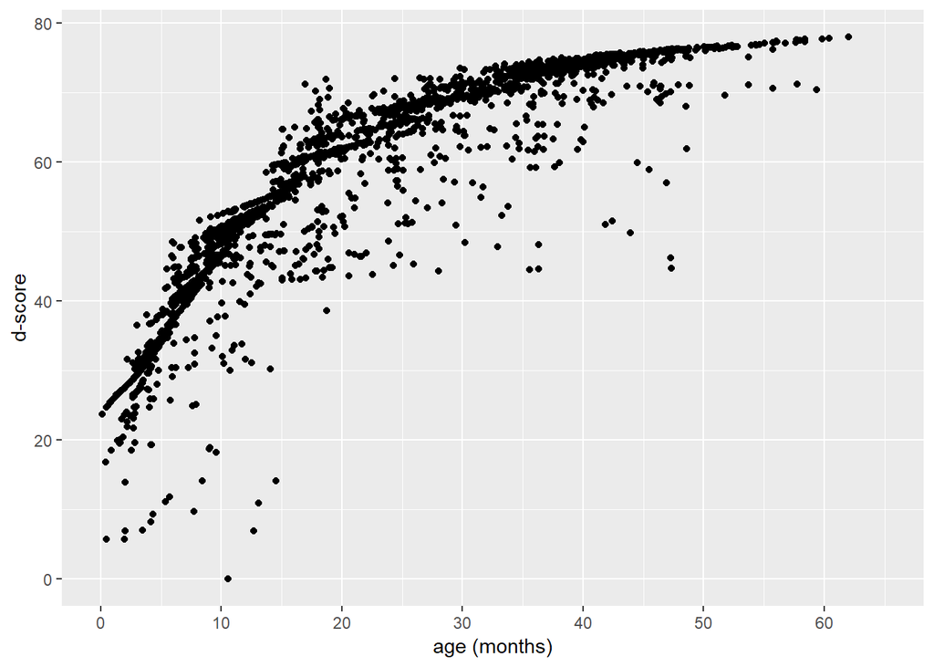

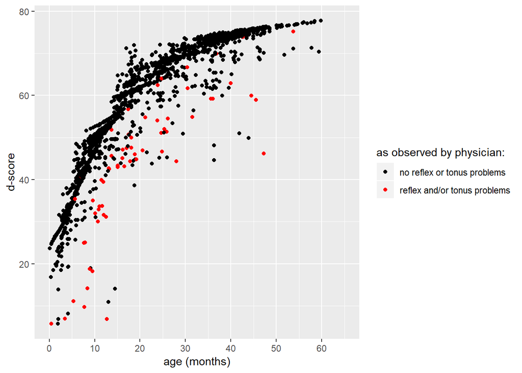

*2064 visits from 1298 children*

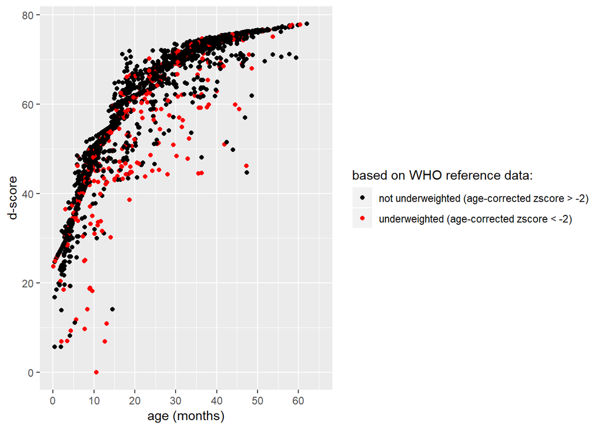

*2323 visits from 1517 children*